# STAT 542 / CS 598: Homework 4

Fall 2019, by Regan Chan (ttchan2)

Due: Monday, Oct 14 by 11:59 PM Pacific Time

## Question 1 [70 Points] Tuning Random Forests in Virtual Twins

Personalized medicine draws a lot of attention in medical research. The goal of personalized medicine is to make a tailored decision for each patient, such that his/her clinical outcome can be optimized. Let’s consider data modified from the [SIDES method](http://biopharmnet.com/subgroup-analysis-software/). In this dataset, 470 patients and 13 variables are observed. You can download the data from our website. The variables are listed below.

- `Health`: health outcome (larger the better)
- `THERAPY`: 1 for active treatment, 0 for the control treatment
- `TIMFIRST`: Time from first sepsis-organ fail to start drug
- `AGE`: Patient age in years
- `BLLPLAT`: Baseline local platelets
- `blSOFA`: Sum of baseline sofa score (cardiovascular, hematology, hepatorenal, and respiration scores)
- `BLLCREAT`: Base creatinine
- `ORGANNUM`: Number of baseline organ failures
- `PRAPACHE`: Pre-infusion apache-ii score
- `BLGCS`: Base GLASGOW coma scale score
- `BLIL6`: Baseline serum IL-6 concentration
- `BLADL`: Baseline activity of daily living score
- `BLLBILI`: Baseline local bilirubin
- `BEST`: The true best treatment suggested by Doctors. **You should not use this variable when fitting the model**!

For each patient, sepsis was observed during their hospital stay. Hence, they need to choose one of the two treatments (indicated by variable `THERAPY`) to prevent further adverse events. After the treatment, their health outcome (`health`) were measured, with a larger value being the better outcome. However, since treatments were assigned randomly, we are not able to suggest better treatment for a new patient. A strategy called [Virtual Twins](https://onlinelibrary.wiley.com/doi/abs/10.1002/sim.4322) was proposed by Foster et al. (2011) to tackle this problem. We consider a simpler version of the method. We fit two random forests to model the outcome `health`: one model uses all patients who received treatment 1, and another model for all patients who received treatment 0. Denote these two models as $\widehat f_1(x)$ and $\widehat f_0(x)$, respectively. When a new patient arrives, we use both models to predict the outcomes and see which model gives a better health status. We will suggest the treatment label associated with the model that gives a larger prediction value. In other words, for a new $x^\ast$, we compare $\widehat f_1(x^\ast)$ and $\widehat f_0(x^\ast)$ and suggest the better lable. The goal for this question is to select tuning parameters for random forest such that it will suggest the best treatment for a patient. Perform the following:

- Randomly split the data into 75% for training and 25% for testing.

```r
sepsis <- read.csv("Sepsis.csv")
n <- nrow(sepsis)
set.seed(0)

genData <- function() {
  trainIdx <<- sample(1:n, n * 0.75)
  trainSet <<- sepsis[trainIdx, ]
  m <<- ncol(trainSet)
  testSet <<- sepsis[-trainIdx,]
}
```

- For the training data, fit the virtual twins model and then use the testing data to suggest the best treatment.
  - You should not use the variable `BEST` when fitting the models

```r
library(randomForest)
set.seed(0)
getRfModel <- function(...) {
  treatment0 <- randomForest(Health ~ .-THERAPY-BEST, data=trainSet[trainSet$THERAPY == 0, ], ...)
  health0 <- predict(treatment0, newdata=trainSet)
  treatment1 <- randomForest(Health ~ .-THERAPY-BEST, data=trainSet[trainSet$THERAPY == 1, ], ...)
  health1 <- predict(treatment1, newdata=trainSet)

  prediction.train <- as.numeric(health1 > health0)
  trainErr <- sum((prediction.train - trainSet$BEST)^2)/nrow(trainSet)

  health0 <- predict(treatment0, newdata=testSet)
  health1 <- predict(treatment1, newdata=testSet)
  prediction.test <- as.numeric(health1 > health0)
  testErr <- sum((prediction.test - testSet$BEST)^2)/nrow(testSet)
  return(list(trainErr=trainErr, testErr=testErr, train=prediction.train, test=prediction.test))
}

getBestErr <- function(...) {
  p <<- m-2  # -1 Because therapy and BEST are removed
  mybest.TrainErr <- Inf
  for(mtry in c(p/3, p/2, p/4)) {
    for(nodesize in c(5, 10, 3)) {
      newErr <- getRfModel(mtry=mtry, nodesize=nodesize)
      if(newErr$trainErr < mybest.TrainErr) {
        mybest.TrainErr <- newErr$trainErr
        mybest.TestErr <- newErr$testErr
        mybest.Mtry <- mtry
        mybest.Nodesize <- nodesize
      }
    }
  }
  return(c(mybest.TrainErr, mybest.TestErr, mybest.Mtry, mybest.Nodesize))
}

genAndTest <- function(...) {
  genData()
  getBestErr()
}

library(parallel)
results <- data.frame(t(mcmapply(genAndTest, 1:100, mc.cores=8)))
```

- Pick three different `mtry` values and three different `nodesize`, leave all other tuning parameters as default
- After predicting the best treatment in the testing data, compare it to the truth `BEST`

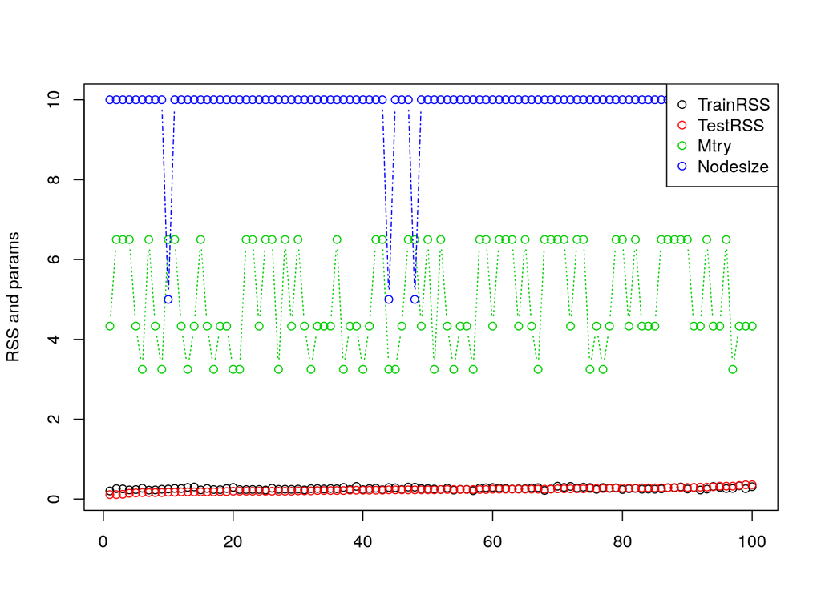

```r
names(results) <- c("TrainRSS", "TestRSS", "Mtry", "Nodesize")
matplot(results[order(results$TestRSS),], type="b", col=1:4, pch=1, ylab="RSS and params")
legend("topright", legend=names(results), col=1:4, pch=1)
```

* Repeat this entire process 100 times and average the prediction errors

```r
mean(results$TestRSS)
```

```
## [1] 0.2305932
```

- Summarize your results, including the model performance and the effect of tuning parameters. Intuitively demonstrate them.

## Question 2 [30 Points] Second Step in Virtual Twins

The second step in a virtual twins model is to use a single tree model (CART) to describe the choice of the best treatment. Perform the following: * Based on your optimal tuning parameter, fit the Virtual Twins model described in Question 1. Again, you should not use the `BEST` variable. * For each subject, obtain the predicted best treatment of the training data itself

```r
library(randomForest)
set.seed(0)
genData()
mymodel <- getRfModel(mtry=13, nodesize=10)
data <- cbind(within(trainSet, rm(BEST), rm(THERAPY)), Y=as.factor(mymodel$train))

library(rpart)
rfModel <- rpart(Y ~ ., data=data)
```

- Treating the label of best treatment as the outcome, and fit a single tree model to predict it. Be careful which variables should be removed from this model fitting.
- Consider tuning the tree model using the cost-complexity tuning.

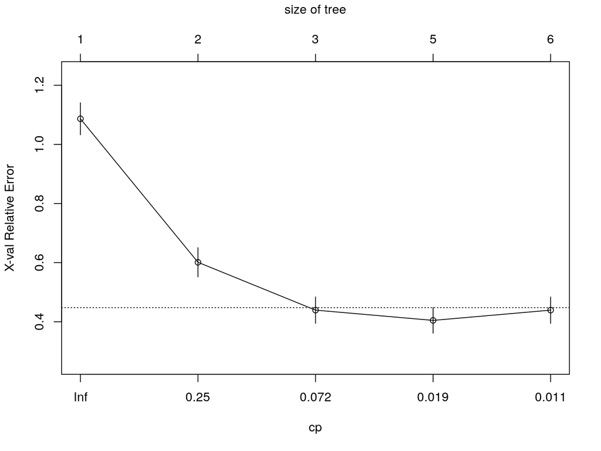

```r
library(ggplot2)
library(rpart.plot)
library(tree)
plotcp(rfModel)
```

[figure not shown]

```r
cptable <- data.frame(rfModel$cptable)
prunedModel <- prune(rfModel, cptable$CP[which.min(cptable$xerror)])
plot(prunedModel)
```

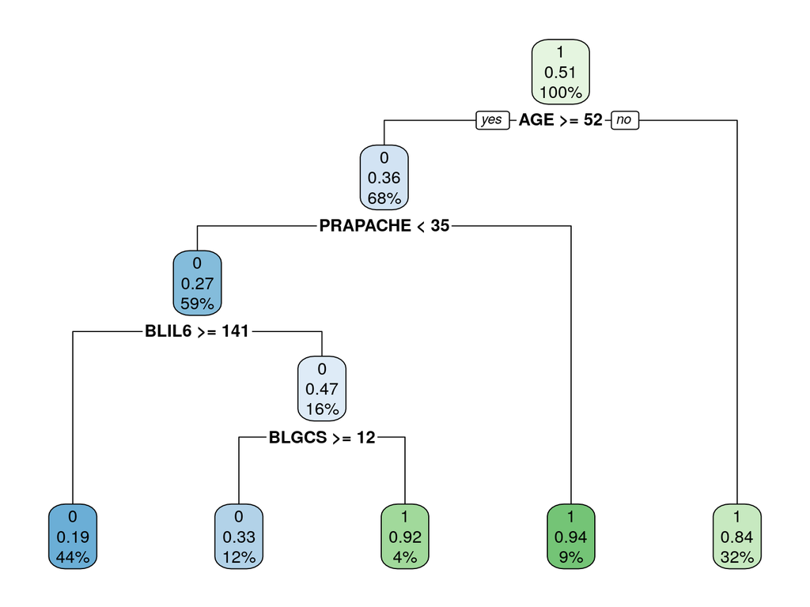

```r
rpart.plot(prunedModel)
```